# Bering Sea Pollock-like Population Simulation test

Comparing Low and High Steepness Scenarios with constant HCR

Author

Jim Ianelli

Published

January 19, 2026

# 1 Introduction

Recruitment productivity under climate change is uncertain, and stock-recruitment steepness ($h$) is a key parameter that drives sustainable harvest levels. Evidence from climate-ecosystem modeling and recruitment studies suggests steepness and productivity can shift with warming and prey dynamics (Hollowed et al. 2020; Holsman et al. 2020; Spencer et al. 2019; Szuwalski et al. 2023). Because steepness informs reference points and F proxies, mis-specification can change expected yields and risk profiles (Szuwalski and Punt 2025; Punt et al. 2024).

At the same time, there is pressure to incorporate environmental covariates into harvest control rules (HCRs) to improve adaptability. These approaches can help track productivity changes, but they also add interpretive uncertainty and require strong validation (Punt et al. 2024; Szuwalski et al. 2023). In contrast, tier-based HCRs remain transparent and easier to communicate, with clear links from biomass to fishing mortality (North Pacific Fishery Management Council 2024). This study asks whether a simple, transparent HCR can be robust to plausible productivity shifts without relying on covariates.

We use a stylized pollock-like, age-structured model and compare two steepness scenarios (h=0.6 and h=0.9) (North Pacific Fishery Management Council 2024). The HCR is held constant (F40% SPR with a biomass ramp from 0.4$B_0$ to 0.05$B_0$), consistent with the Tier 3 framework used for Bering Sea groundfish (North Pacific Fishery Management Council 2024; Ianelli et al. 2011). The goal is to evaluate whether a single rule performs reasonably across both low and high productivity regimes, and to quantify the tradeoffs if productivity assumptions are wrong (Szuwalski and Punt 2025).

Key design choices include: - 15 age classes with Bering Sea-like growth and maturity schedules (Ianelli et al. 2011) - Beverton-Holt recruitment with lognormal variability (CV 0.7) (Spencer et al. 2019) - 50-year projections with 100 Monte Carlo replicates per scenario - No explicit environmental covariates; steepness shifts serve as a reduced-form proxy for climate-driven productivity changes (Hollowed et al. 2020; Holsman et al. 2020)

Outputs include reference points, time series of biomass and catch, and sensitivity comparisons across steepness values. We move from model setup to reference points in Table 1, then visualize recruitment and yield tradeoffs in Figure 1 and Figure 2. Simulation outcomes are summarized in Figure 4 and Figure 5, with sensitivity results in Figure 6, similar to HCR robustness evaluations in recent studies (Punt et al. 2024).

# 2 Model Description

This section documents the equations and inputs used to generate the reference points and simulations shown later.

## 2.1 Population Dynamics

We define the annual accounting that drives the time series trajectories shown in Figure 4.

### 2.1.1 Numbers at Age

The population is tracked as numbers-at-age $N_{a,t}$ where $a$ denotes age and $t$ denotes year. The population evolves according to:

**Recruitment (age 1):**
$$N_{1,t} = R_t$$

**Ages 2 through 14:**
$$N_{a,t} = N_{a-1,t-1} \cdot e^{-Z_{a-1,t-1}}$$

**Plus group (age 15):**
$$N_{15,t} = N_{14,t-1} \cdot e^{-Z_{14,t-1}} + N_{15,t-1} \cdot e^{-Z_{15,t-1}}$$

where $Z_{a,t} = M + F_t \cdot s_a$ is the total instantaneous mortality rate.

These equations determine the age structure that feeds into biomass and catch trajectories in Figure 4.

## 2.2 Biological Parameters

Biological inputs control growth, maturity, and vulnerability, which in turn shape the yield curves in Figure 2 and the SSB trends in Figure 4.

### 2.2.1 Weight-at-Age

Weight-at-age is specified empirically based on the updated schedule:

| Age | 1 | 2 | 3 | 4 | 5 | 6 | 7 | 8 | 9 | 10 | 11 | 12 | 13 | 14 | 15+ |
| --- | --- | --- | --- | --- | --- | --- | --- | --- | --- | --- | --- | --- | --- | --- | --- |
| Weight (kg) | 0.029 | 0.180 | 0.372 | 0.491 | 0.613 | 0.749 | 0.883 | 1.014 | 1.133 | 1.243 | 1.348 | 1.388 | 1.469 | 1.553 | 1.791 |

These weights translate numbers-at-age into biomass and catch, which are summarized in Figure 4 and Figure 2.

### 2.2.2 Maturity and Selectivity

Maturity is specified directly using fixed proportions at age, while fishery selectivity follows a logistic function:

| Age | 1 | 2 | 3 | 4 | 5 | 6 | 7 | 8 | 9 | 10 | 11 | 12 | 13 | 14 | 15+ |
| --- | --- | --- | --- | --- | --- | --- | --- | --- | --- | --- | --- | --- | --- | --- | --- |
| Proportion mature | 0.000 | 0.008 | 0.289 | 0.641 | 0.842 | 0.901 | 0.947 | 0.963 | 0.970 | 1.000 | 1.000 | 1.000 | 1.000 | 1.000 | 1.000 |

$$s_a = \frac{1}{1 + e^{-\gamma_s(a - a_{50}^s)}} \quad \text{with } a_{50}^s = 4.0$$

Maturity governs SSB while selectivity determines fishing impact, which together shape the trajectories in Figure 4.

### 2.2.3 Spawning Stock Biomass

SSB is defined as **female spawning biomass only**:

$$SSB_t = \sum_{a=1}^{15} N_{a,t} \cdot W_a \cdot m_a \cdot 0.5$$

This definition is used directly in the SSB time series shown in Figure 4 and the Monte Carlo envelope in Figure 5.

## 2.3 Stock-Recruitment Relationship

Recruitment dynamics are summarized visually in Figure 1 and influence the variability seen in Figure 5.

### 2.3.1 Beverton-Holt Model with Steepness

The expected recruitment follows the Beverton-Holt stock-recruitment relationship:

$$R_t = \frac{4hR_0 \cdot SSB_{t-1}}{SSB_0(1-h) + SSB_{t-1}(5h-1)}$$

Where **steepness** ($h$) represents the fraction of $R_0$ produced when SSB is at 20% of unfished levels. Higher steepness indicates a more resilient stock that maintains recruitment even at lower biomass levels.

As shown in Figure 1, this formulation differs across the two steepness scenarios.

### 2.3.2 Recruitment Variability

Recruitment includes multiplicative log-normal process error with CV = 0.7:

$$R_t = \bar{R}_t \cdot e^{\epsilon_t - \sigma_R^2/2}$$

This stochasticity drives the spread in Figure 5 and contributes to the variability summarized in Table 4.

# 3 Scenario Setup

We instantiate the two steepness scenarios used throughout the tables and figures.

```r
# Create two scenarios with different steepness values
scenario_low <- create_scenario(h = 0.6, "Low steepness (h=0.6)")
scenario_high <- create_scenario(h = 0.9, "High steepness (h=0.9)")
scenarios <- list(scenario_low, scenario_high)
```

These objects feed the reference points in Table 1 and the graphical comparisons in Figure 1 and Figure 2.

All simulations initialize the population at the scenario’s Fmsy equilibrium rather than the unfished B0 state.

# 4 Reference Point Comparison

We summarize equilibrium reference points for each scenario to quantify differences in Fmsy, Bmsy, and MSY (see Table 1).

```r
comparison_df <- compare_reference_points(scenarios)
knitr::kable(comparison_df, align = c("l", "c", "c", "c", "c", "c", "c", "c"))
```

Table 1: Reference point comparison between low and high steepness scenarios

| Scenario | Steepness | Fmsy | Bmsy (Mt) | MSY (Mt) | SSB0 (Mt) | Bmsy/SSB0 | R_msy (B) |
| --- | --- | --- | --- | --- | --- | --- | --- |
| Low steepness (h=0.6) | 0.6 | 0.3517 | 2.66 | 1.31 | 8.29 | 0.321 | 9.98 |
| High steepness (h=0.9) | 0.9 | 1.2805 | 1.59 | 2.00 | 8.29 | 0.192 | 12.08 |

Table 1 provides the numeric basis for the contrasts discussed below and for the vertical markers in Figure 2.

## 4.1 Key Differences

```r
ref_low <- scenario_low$ref_points
ref_high <- scenario_high$ref_points
```

We expand on the table summary by translating the reference point differences into percent changes.

The contrast between scenarios reveals important management implications:

| Metric | Low Steepness (h=0.6) | High Steepness (h=0.9) | Change |
| --- | --- | --- | --- |
| $F_{MSY}$ | 0.352 | 1.28 | 264% higher |
| $B_{MSY}$ (Mt) | 2.66 | 1.59 | -40% lower |
| MSY (Mt) | 1.31 | 2 | 53% higher |
| $B_{MSY}/SSB_0$ | 0.321 | 0.192 | -40% lower |

**Interpretation:**

- **Higher steepness allows higher fishing mortality**: With $h = 0.9$, the stock can sustain $F_{MSY}$ = 1.28 compared to only 0.35 for $h = 0.6$.
- **Higher steepness produces higher MSY**: The more productive stock yields 2 million tonnes vs. 1.31 million tonnes.
- **Higher steepness requires lower $B_{MSY}$**: The stock can be fished down further while still achieving MSY.

# 5 Graphical Comparisons

These figures visualize how the two steepness settings diverge in recruitment, yield, and harvest control (see Figure 1, Figure 2, and Figure 3).

## 5.1 Stock-Recruitment Curves

As shown in Figure 1, the stock-recruitment curves differ and highlight the different Bmsy locations.

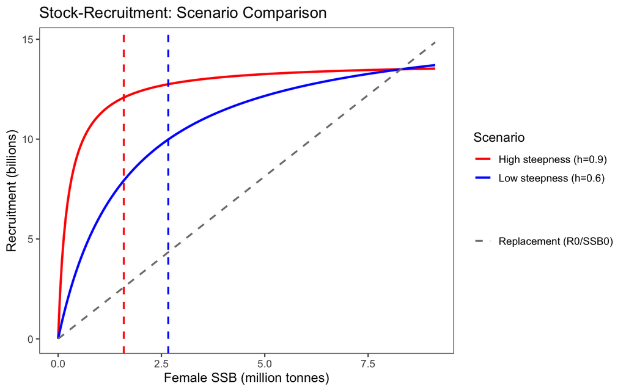

Figure 1: Stock-recruitment relationships for low (h=0.6) and high (h=0.9) steepness scenarios. Vertical dashed lines indicate Bmsy for each scenario and the gray dashed line is the replacement line (R0/SSB0).

```r
plot_sr_comparison(scenarios, colors = c("blue", "red"))
```

The stock-recruitment curves illustrate how steepness affects the relationship between spawning biomass and recruitment:

- **Low steepness (blue)**: Recruitment declines more steeply as SSB decreases, making the stock more vulnerable to overfishing.
- **High steepness (red)**: Recruitment remains relatively high even at reduced SSB, indicating greater resilience.

## 5.2 Yield Curves

As shown in Figure 2, equilibrium yield responds differently to fishing mortality across scenarios.

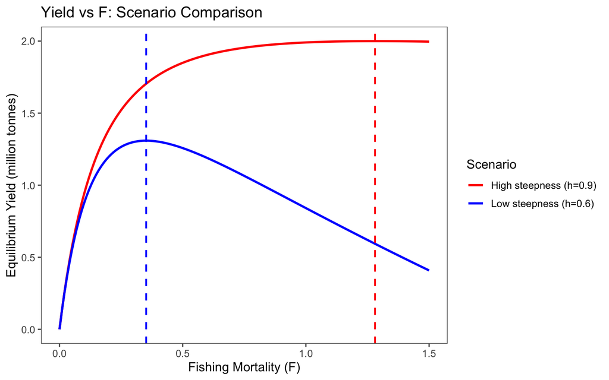

Figure 2: Equilibrium yield vs. fishing mortality for both steepness scenarios. Vertical dashed lines indicate Fmsy for each scenario.

```r
plot_yield_comparison(scenarios, colors = c("blue", "red"))
```

The yield curves show:

- **Low steepness (blue)**: Yield peaks at a lower $F$ and declines more rapidly with overfishing.
- **High steepness (red)**: Yield peaks at a much higher $F$ and the curve is flatter, providing more buffer against recruitment overfishing.

## 5.3 Harvest Control Rule (F40% with biomass ramp)

We add a sloping harvest control rule based on $F_{40\%}$ (SPR) and unfished biomass $B_0$. The target F values are reported in Table 2 and the rule shape is shown in Figure 3.

$$F_t =
\begin{cases}
F_{40\%} & \text{if } SSB_t \ge 0.4 B_0 \\
F_{40\%} \cdot \dfrac{SSB_t - 0.05 B_0}{0.4 B_0 - 0.05 B_0} & \text{if } 0.05 B_0 < SSB_t < 0.4 B_0 \\
0 & \text{if } SSB_t \le 0.05 B_0
\end{cases}$$

```r
F40_low <- calc_F_spr(scenario_low$params, spr_target = 0.4)
F40_high <- calc_F_spr(scenario_high$params, spr_target = 0.4)

f40_table <- data.frame(
  Scenario = c("Low steepness (h=0.6)", "High steepness (h=0.9)"),
  `F40%` = round(c(F40_low, F40_high), 3),
  check.names = FALSE
)

knitr::kable(f40_table)
```

Table 2: F40% (SPR) values by steepness scenario.

| Scenario | F40% |
| --- | --- |
| Low steepness (h=0.6) | 0.412 |
| High steepness (h=0.9) | 0.412 |

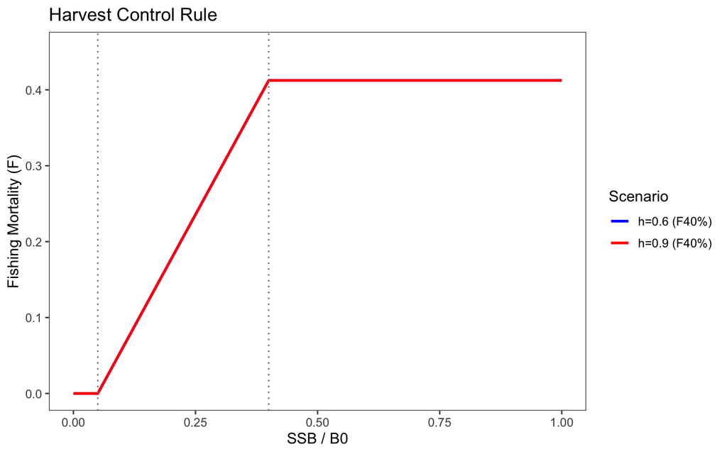

Figure 3: Sloping control rule: F40% above 0.4 B0, ramp to zero at 0.05 B0.

```r
ssb_ratio <- seq(0, 1, by = 0.01)

F_hcr_low <- calc_sloping_hcr(ssb_ratio * ref_low$SSB0, ref_low$SSB0, F40_low)
F_hcr_high <- calc_sloping_hcr(ssb_ratio * ref_high$SSB0, ref_high$SSB0, F40_high)

y_max <- max(c(F_hcr_low, F_hcr_high)) * 1.1

hcr_df <- data.frame(
  SSB_ratio = rep(ssb_ratio, 2),
  F = c(F_hcr_low, F_hcr_high),
  Scenario = rep(c("h=0.6 (F40%)", "h=0.9 (F40%)"), each = length(ssb_ratio))
)

hcr_colors <- c("h=0.6 (F40%)" = "blue", "h=0.9 (F40%)" = "red")

p_hcr <- ggplot(hcr_df, aes(x = SSB_ratio, y = F, color = Scenario)) +
  geom_line(size = 1) +
  geom_vline(xintercept = c(0.05, 0.4), linetype = "dotted", color = "gray50") +
  coord_cartesian(ylim = c(0, y_max)) +
  labs(x = "SSB / B0", y = "Fishing Mortality (F)", title = "Harvest Control Rule") +
  scale_color_manual(values = hcr_colors) +
  ggthemes::theme_few()

p_hcr
```

# 6 Simulation Results

We first compare single realizations at Fmsy (Figure 4), then summarize means (Table 3) and variability across Monte Carlo runs (Figure 5 and Table 4).

## 6.1 Single Simulation Comparison

As shown in Figure 4, we plot a single 50-year trajectory for each scenario at its Fmsy.

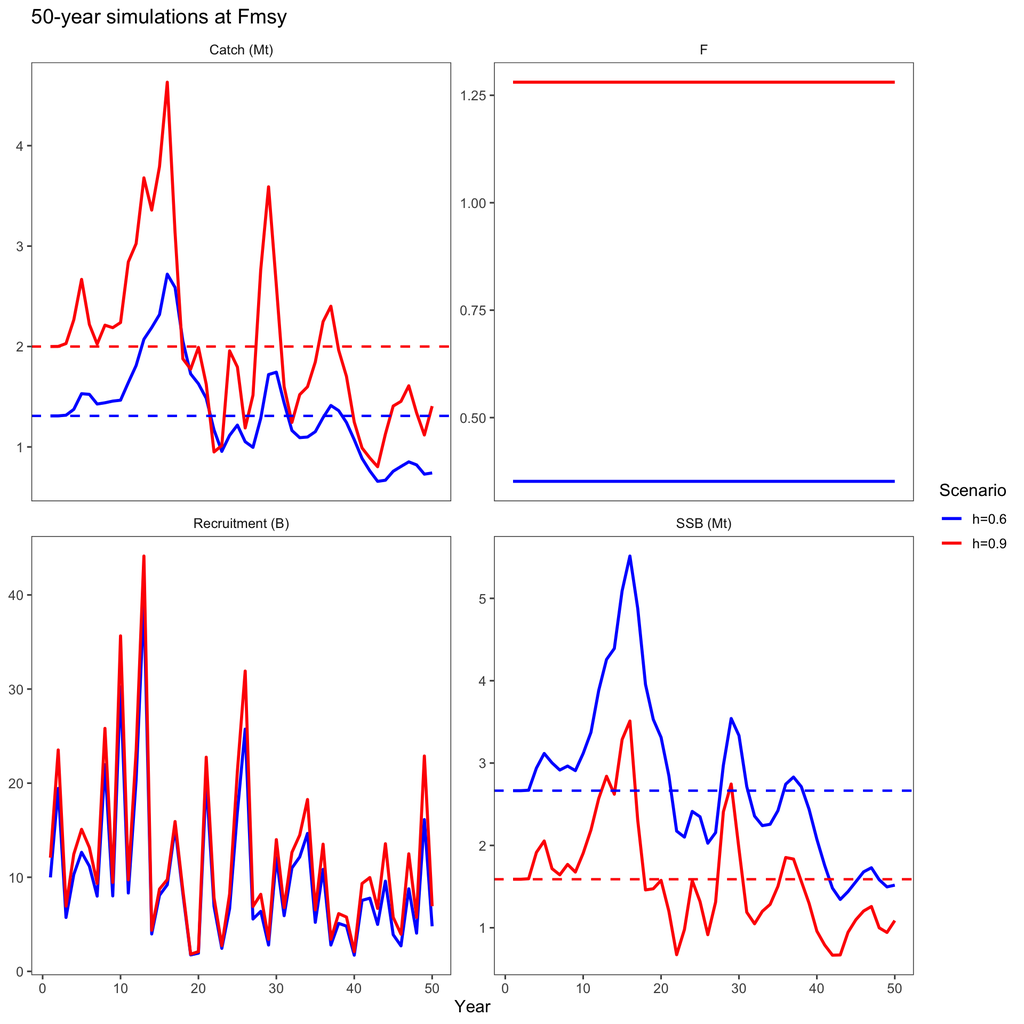

Figure 4: 50-year simulations for both scenarios at their respective Fmsy values (single Monte Carlo draw).

```r
# Run simulations
sim_low <- run_simulation(scenario_low$params, F_series = ref_low$Fmsy, seed = 42)
sim_high <- run_simulation(scenario_high$params, F_series = ref_high$Fmsy, seed = 42)

years <- 1:50

make_long <- function(sim, scenario_label) {
  data.frame(
    Year = rep(years, 4),
    Scenario = scenario_label,
    Metric = rep(c("SSB (Mt)", "Recruitment (B)", "Catch (Mt)", "F"), each = length(years)),
    Value = c(sim$SSB / 1e9, sim$Recruitment / 1e9, sim$Catch / 1e9, sim$F)
  )
}

sim_long <- rbind(
  make_long(sim_low, "h=0.6"),
  make_long(sim_high, "h=0.9")
)

sim_long$Metric <- factor(
  sim_long$Metric,
  levels = c("SSB (Mt)", "Recruitment (B)", "Catch (Mt)", "F")
)

ref_lines <- data.frame(
  Metric = c("SSB (Mt)", "SSB (Mt)", "Catch (Mt)", "Catch (Mt)"),
  Scenario = c("h=0.6", "h=0.9", "h=0.6", "h=0.9"),
  Value = c(ref_low$Bmsy / 1e9, ref_high$Bmsy / 1e9, ref_low$MSY / 1e9, ref_high$MSY / 1e9)
)

scenario_colors <- c("h=0.6" = "blue", "h=0.9" = "red")

p_single <- ggplot(sim_long, aes(x = Year, y = Value, color = Scenario)) +
  geom_line(size = 1) +
  geom_hline(
    data = ref_lines,
    aes(yintercept = Value, color = Scenario),
    linetype = "dashed",
    size = 0.8,
    inherit.aes = FALSE,
    show.legend = FALSE
  ) +
  facet_wrap(~ Metric, scales = "free_y", ncol = 2) +
  scale_color_manual(values = scenario_colors) +
  labs(x = "Year", y = NULL, title = "50-year simulations at Fmsy") +
  ggthemes::theme_few()

p_single
```

## 6.2 Simulation Summary Statistics

Table 3 aggregates the single-simulation outcomes into mean and CV metrics.

```r
summary_df <- data.frame(
  Scenario = c("Low steepness (h=0.6)", "High steepness (h=0.9)"),
  `Mean SSB (Mt)` = c(round(mean(sim_low$SSB)/1e9, 2), round(mean(sim_high$SSB)/1e9, 2)),
  `CV SSB` = c(round(sd(sim_low$SSB)/mean(sim_low$SSB), 3),
               round(sd(sim_high$SSB)/mean(sim_high$SSB), 3)),
  `Mean Catch (Mt)` = c(round(mean(sim_low$Catch)/1e9, 2), round(mean(sim_high$Catch)/1e9, 2)),
  `Mean Rec (B)` = c(round(mean(sim_low$Recruitment)/1e9, 2),
                     round(mean(sim_high$Recruitment)/1e9, 2)),
  check.names = FALSE
)

knitr::kable(summary_df)
```

Table 3: Summary statistics from 50-year simulations at respective Fmsy values

| Scenario | Mean SSB (Mt) | CV SSB | Mean Catch (Mt) | Mean Rec (B) |
| --- | --- | --- | --- | --- |
| Low steepness (h=0.6) | 2.75 | 0.352 | 1.35 | 10.09 |
| High steepness (h=0.9) | 1.60 | 0.413 | 2.01 | 12.13 |

## 6.3 Monte Carlo Simulations

As shown in Figure 5, stochastic variability across 100 runs is summarized with metrics reported in Table 4.

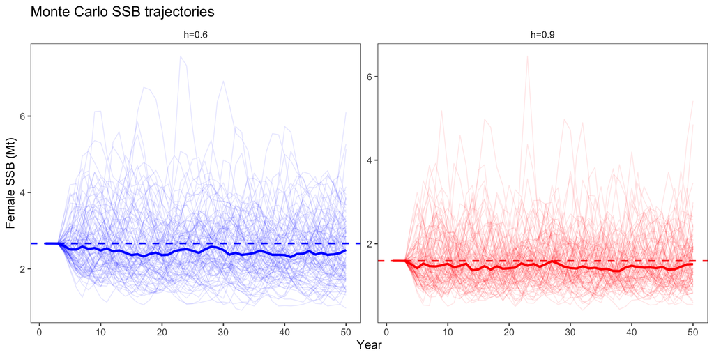

Figure 5: Ensemble of 100 simulations for each scenario showing SSB variability. Thin lines are individual simulations, thick solid lines are medians, and dashed lines indicate Bmsy.

```r
# Run Monte Carlo simulations
n_sims <- 100
n_years <- 50

ssb_low <- matrix(NA, n_years, n_sims)
ssb_high <- matrix(NA, n_years, n_sims)
catch_low <- matrix(NA, n_years, n_sims)
catch_high <- matrix(NA, n_years, n_sims)

for (i in 1:n_sims) {
  sim_l <- run_simulation(scenario_low$params, F_series = ref_low$Fmsy, seed = i)
  sim_h <- run_simulation(scenario_high$params, F_series = ref_high$Fmsy, seed = i)
  ssb_low[, i] <- sim_l$SSB
  ssb_high[, i] <- sim_h$SSB
  catch_low[, i] <- sim_l$Catch
  catch_high[, i] <- sim_h$Catch
}

ssb_low_df <- data.frame(
  Year = rep(1:n_years, times = n_sims),
  Sim = rep(1:n_sims, each = n_years),
  SSB = as.vector(ssb_low) / 1e9,
  Scenario = "h=0.6"
)

ssb_high_df <- data.frame(
  Year = rep(1:n_years, times = n_sims),
  Sim = rep(1:n_sims, each = n_years),
  SSB = as.vector(ssb_high) / 1e9,
  Scenario = "h=0.9"
)

ssb_df <- rbind(ssb_low_df, ssb_high_df)

median_df <- rbind(
  data.frame(Year = 1:n_years, SSB = apply(ssb_low, 1, median) / 1e9, Scenario = "h=0.6"),
  data.frame(Year = 1:n_years, SSB = apply(ssb_high, 1, median) / 1e9, Scenario = "h=0.9")
)

bmsy_df <- data.frame(
  Scenario = c("h=0.6", "h=0.9"),
  Bmsy = c(ref_low$Bmsy, ref_high$Bmsy) / 1e9
)

scenario_colors <- c("h=0.6" = "blue", "h=0.9" = "red")

p_mc <- ggplot(ssb_df, aes(x = Year, y = SSB, group = interaction(Scenario, Sim), color = Scenario)) +
  geom_line(alpha = 0.1, size = 0.4, show.legend = FALSE) +
  geom_line(
    data = median_df,
    aes(x = Year, y = SSB, color = Scenario),
    size = 1.1,
    inherit.aes = FALSE
  ) +
  geom_hline(
    data = bmsy_df,
    aes(yintercept = Bmsy, color = Scenario),
    linetype = "dashed",
    size = 0.8,
    inherit.aes = FALSE
  ) +
  facet_wrap(~ Scenario, ncol = 2, scales = "free_y") +
  scale_color_manual(values = scenario_colors) +
  labs(x = "Year", y = "Female SSB (Mt)", title = "Monte Carlo SSB trajectories") +
  ggthemes::theme_few() +
  guides(color = "none")

p_mc
```

```r
mc_stats <- data.frame(
  Scenario = c("Low steepness (h=0.6)", "High steepness (h=0.9)"),
  `Mean terminal SSB (Mt)` = c(round(mean(ssb_low[n_years,])/1e9, 2),
                                round(mean(ssb_high[n_years,])/1e9, 2)),
  `P(SSB < Bmsy) terminal` = c(round(mean(ssb_low[n_years,] < ref_low$Bmsy), 2),
                                round(mean(ssb_high[n_years,] < ref_high$Bmsy), 2)),
  `Mean catch (Mt)` = c(round(mean(catch_low)/1e9, 2),
                        round(mean(catch_high)/1e9, 2)),
  `CV mean catch` = c(round(sd(colMeans(catch_low))/mean(catch_low), 3),
                      round(sd(colMeans(catch_high))/mean(catch_high), 3)),
  check.names = FALSE
)

knitr::kable(mc_stats)
```

Table 4: Monte Carlo simulation statistics (100 runs per scenario)

| Scenario | Mean terminal SSB (Mt) | P(SSB < Bmsy) terminal | Mean catch (Mt) | CV mean catch |
| --- | --- | --- | --- | --- |
| Low steepness (h=0.6) | 2.58 | 0.56 | 1.26 | 0.134 |
| High steepness (h=0.9) | 1.64 | 0.54 | 1.96 | 0.105 |

# 7 Fishing Mortality Sensitivity

To stress-test harvest rates, we run each scenario at constant fishing mortality values spanning 0.5-1.5 x $F_{MSY}$. Table 5 lists the constant-F results, and Figure 6 adds the FSPR harvest control rule (F40% target with the biomass ramp) plus a capped variant where catch cannot exceed 1.45 Mt.

```r
F_multipliers <- c(0.5, 0.75, 1.0, 1.25, 1.5)
n_sims_F <- 100

f_low <- run_F_sensitivity(scenario_low, F_multipliers, n_sims = n_sims_F, seed = 200)
f_high <- run_F_sensitivity(scenario_high, F_multipliers, n_sims = n_sims_F, seed = 500)

f_summary <- rbind(f_low, f_high)

f_table <- data.frame(
  Scenario = f_summary$Scenario,
  `F multiplier` = f_summary$F_multiplier,
  `F applied` = round(f_summary$F_applied, 3),
  `Mean SSB (Mt)` = round(f_summary$Mean_SSB / 1e9, 2),
  `Terminal SSB (Mt)` = round(f_summary$Terminal_SSB / 1e9, 2),
  `P(SSB < Bmsy) terminal` = round(f_summary$P_SSB_lt_Bmsy, 2),
  `Mean Catch (Mt)` = round(f_summary$Mean_Catch / 1e9, 2),
  check.names = FALSE
)

knitr::kable(f_table)
```

Table 5: Performance across constant F multipliers of Fmsy (100 simulations per level).

| Scenario | F multiplier | F applied | Mean SSB (Mt) | Terminal SSB (Mt) | P(SSB < Bmsy) terminal | Mean Catch (Mt) |
| --- | --- | --- | --- | --- | --- | --- |
| Low steepness (h=0.6) | 0.50 | 0.176 | 4.11 | 4.32 | 0.08 | 1.10 |
| Low steepness (h=0.6) | 0.75 | 0.264 | 3.22 | 3.30 | 0.29 | 1.24 |
| Low steepness (h=0.6) | 1.00 | 0.352 | 2.67 | 2.50 | 0.61 | 1.31 |
| Low steepness (h=0.6) | 1.25 | 0.440 | 2.19 | 2.17 | 0.76 | 1.29 |
| Low steepness (h=0.6) | 1.50 | 0.528 | 1.87 | 1.72 | 0.90 | 1.27 |
| High steepness (h=0.9) | 0.50 | 0.640 | 2.37 | 2.52 | 0.08 | 1.85 |
| High steepness (h=0.9) | 0.75 | 0.960 | 1.85 | 1.90 | 0.45 | 1.93 |
| High steepness (h=0.9) | 1.00 | 1.280 | 1.55 | 1.45 | 0.67 | 1.95 |
| High steepness (h=0.9) | 1.25 | 1.601 | 1.39 | 1.29 | 0.77 | 2.01 |
| High steepness (h=0.9) | 1.50 | 1.921 | 1.21 | 1.19 | 0.89 | 1.96 |

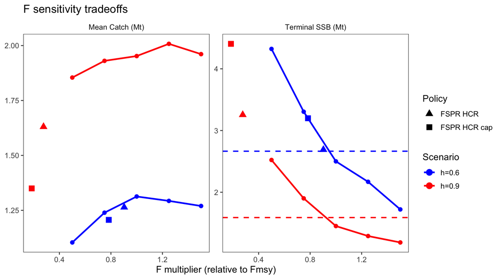

Figure 6: Tradeoffs across F multipliers: mean catch and terminal SSB. Triangle points show the FSPR HCR outcome and square points show the catch-capped HCR at the mean realized F/Fmsy.

```r
plot_data <- f_summary
plot_data$Policy <- "Constant F"
plot_data$Scenario_plot <- ifelse(
  plot_data$Scenario == scenario_low$name,
  "h=0.6",
  "h=0.9"
)

catch_cap <- 1.45e9

run_hcr_summary <- function(scenario, F_target, B0, n_sims, seed_base, catch_cap, policy_label) {
  params <- scenario$params
  ref_points <- scenario$ref_points
  n_years <- params$n_years

  ssb_mean <- numeric(n_sims)
  ssb_terminal <- numeric(n_sims)
  catch_mean <- numeric(n_sims)
  f_mean <- numeric(n_sims)

  for (i in 1:n_sims) {
    sim <- run_simulation_hcr(
      params,
      F_target = F_target,
      B0 = B0,
      catch_cap = catch_cap,
      seed = seed_base + i
    )
    ssb_mean[i] <- mean(sim$SSB)
    ssb_terminal[i] <- sim$SSB[n_years]
    catch_mean[i] <- mean(sim$Catch)
    f_mean[i] <- mean(sim$F)
  }

  data.frame(
    Scenario = scenario$name,
    F_multiplier = mean(f_mean) / ref_points$Fmsy,
    Mean_SSB = mean(ssb_mean),
    Terminal_SSB = mean(ssb_terminal),
    Mean_Catch = mean(catch_mean),
    Policy = policy_label
  )
}

hcr_low <- run_hcr_summary(
  scenario_low,
  F40_low,
  ref_low$SSB0,
  n_sims_F,
  seed_base = 800,
  catch_cap = NULL,
  policy_label = "FSPR HCR"
)
hcr_high <- run_hcr_summary(
  scenario_high,
  F40_high,
  ref_high$SSB0,
  n_sims_F,
  seed_base = 900,
  catch_cap = NULL,
  policy_label = "FSPR HCR"
)
hcr_low_cap <- run_hcr_summary(
  scenario_low,
  F40_low,
  ref_low$SSB0,
  n_sims_F,
  seed_base = 1000,
  catch_cap = catch_cap,
  policy_label = "FSPR HCR cap"
)
hcr_high_cap <- run_hcr_summary(
  scenario_high,
  F40_high,
  ref_high$SSB0,
  n_sims_F,
  seed_base = 1100,
  catch_cap = catch_cap,
  policy_label = "FSPR HCR cap"
)
hcr_summary <- rbind(hcr_low, hcr_high, hcr_low_cap, hcr_high_cap)
hcr_summary$Scenario_plot <- ifelse(
  hcr_summary$Scenario == scenario_low$name,
  "h=0.6",
  "h=0.9"
)

plot_long <- rbind(
  data.frame(
    F_multiplier = plot_data$F_multiplier,
    Scenario = plot_data$Scenario_plot,
    Metric = "Mean Catch (Mt)",
    Value = plot_data$Mean_Catch / 1e9,
    Policy = plot_data$Policy
  ),
  data.frame(
    F_multiplier = plot_data$F_multiplier,
    Scenario = plot_data$Scenario_plot,
    Metric = "Terminal SSB (Mt)",
    Value = plot_data$Terminal_SSB / 1e9,
    Policy = plot_data$Policy
  ),
  data.frame(
    F_multiplier = hcr_summary$F_multiplier,
    Scenario = hcr_summary$Scenario_plot,
    Metric = "Mean Catch (Mt)",
    Value = hcr_summary$Mean_Catch / 1e9,
    Policy = hcr_summary$Policy
  ),
  data.frame(
    F_multiplier = hcr_summary$F_multiplier,
    Scenario = hcr_summary$Scenario_plot,
    Metric = "Terminal SSB (Mt)",
    Value = hcr_summary$Terminal_SSB / 1e9,
    Policy = hcr_summary$Policy
  )
)

plot_long$Metric <- factor(plot_long$Metric, levels = c("Mean Catch (Mt)", "Terminal SSB (Mt)"))

bmsy_df <- data.frame(
  Scenario = c("h=0.6", "h=0.9"),
  Metric = "Terminal SSB (Mt)",
  Value = c(ref_low$Bmsy, ref_high$Bmsy) / 1e9
)

scenario_colors <- c("h=0.6" = "blue", "h=0.9" = "red")

p_f <- ggplot() +
  geom_line(
    data = plot_long[plot_long$Policy == "Constant F", ],
    aes(x = F_multiplier, y = Value, color = Scenario),
    size = 1
  ) +
  geom_point(
    data = plot_long[plot_long$Policy == "Constant F", ],
    aes(x = F_multiplier, y = Value, color = Scenario),
    size = 2
  ) +
  geom_point(
    data = plot_long[plot_long$Policy != "Constant F", ],
    aes(x = F_multiplier, y = Value, color = Scenario, shape = Policy),
    size = 3,
    stroke = 0.8
  ) +
  geom_hline(
    data = bmsy_df,
    aes(yintercept = Value, color = Scenario),
    linetype = "dashed",
    size = 0.8,
    inherit.aes = FALSE,
    show.legend = FALSE
  ) +
  facet_wrap(~ Metric, scales = "free_y", ncol = 2) +
  scale_color_manual(values = scenario_colors) +
  scale_shape_manual(values = c("FSPR HCR" = 17, "FSPR HCR cap" = 15)) +
  labs(x = "F multiplier (relative to Fmsy)", y = NULL, title = "F sensitivity tradeoffs") +
  ggthemes::theme_few()

p_f
```

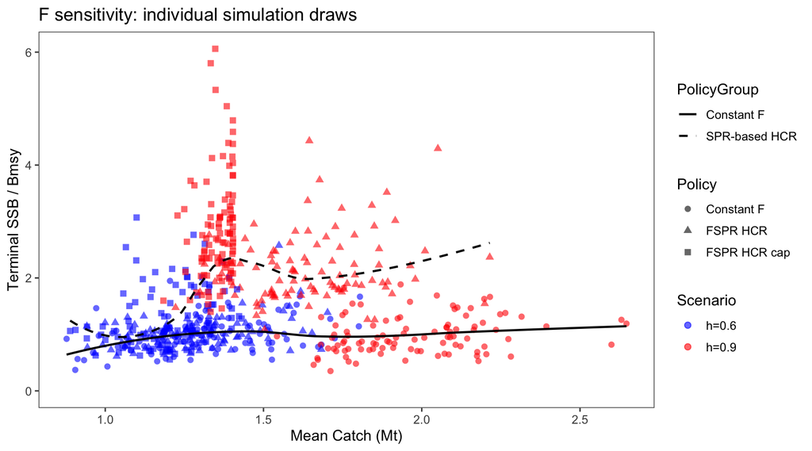

Figure 7: Individual simulation outcomes at F multiplier = 1.0 and under the FSPR HCR (with and without a 1.45 Mt catch cap). Points are single Monte Carlo draws with x = mean catch and y = terminal SSB/Bmsy.

```r
n_sims_points <- n_sims_F
catch_cap <- 1.45e9

sim_constant_points <- function(scenario, f_multiplier, seed_base, n_sims) {
  params <- scenario$params
  ref_points <- scenario$ref_points
  n_years <- params$n_years

  mean_catch <- numeric(n_sims)
  terminal_ssb <- numeric(n_sims)

  for (i in 1:n_sims) {
    sim <- run_simulation(params, F_series = ref_points$Fmsy * f_multiplier, seed = seed_base + i)
    mean_catch[i] <- mean(sim$Catch)
    terminal_ssb[i] <- sim$SSB[n_years]
  }

  data.frame(
    Scenario = scenario$name,
    F_multiplier = rep(f_multiplier, n_sims),
    Mean_Catch = mean_catch,
    Terminal_SSB = terminal_ssb,
    Policy = "Constant F"
  )
}

sim_hcr_points <- function(scenario, F_target, B0, seed_base, n_sims, catch_cap, policy_label) {
  params <- scenario$params
  ref_points <- scenario$ref_points
  n_years <- params$n_years

  mean_catch <- numeric(n_sims)
  terminal_ssb <- numeric(n_sims)
  mean_f <- numeric(n_sims)

  for (i in 1:n_sims) {
    sim <- run_simulation_hcr(
      params,
      F_target = F_target,
      B0 = B0,
      catch_cap = catch_cap,
      seed = seed_base + i
    )
    mean_catch[i] <- mean(sim$Catch)
    terminal_ssb[i] <- sim$SSB[n_years]
    mean_f[i] <- mean(sim$F)
  }

  data.frame(
    Scenario = scenario$name,
    F_multiplier = mean_f / ref_points$Fmsy,
    Mean_Catch = mean_catch,
    Terminal_SSB = terminal_ssb,
    Policy = policy_label
  )
}

const_low_pts <- sim_constant_points(scenario_low, 1.0, seed_base = 1200, n_sims_points)
const_high_pts <- sim_constant_points(scenario_high, 1.0, seed_base = 1300, n_sims_points)
hcr_low_pts <- sim_hcr_points(
  scenario_low,
  F40_low,
  ref_low$SSB0,
  seed_base = 1400,
  n_sims_points,
  catch_cap = NULL,
  policy_label = "FSPR HCR"
)
hcr_high_pts <- sim_hcr_points(
  scenario_high,
  F40_high,
  ref_high$SSB0,
  seed_base = 1500,
  n_sims_points,
  catch_cap = NULL,
  policy_label = "FSPR HCR"
)
hcr_low_cap_pts <- sim_hcr_points(
  scenario_low,
  F40_low,
  ref_low$SSB0,
  seed_base = 1600,
  n_sims_points,
  catch_cap = catch_cap,
  policy_label = "FSPR HCR cap"
)
hcr_high_cap_pts <- sim_hcr_points(
  scenario_high,
  F40_high,
  ref_high$SSB0,
  seed_base = 1700,
  n_sims_points,
  catch_cap = catch_cap,
  policy_label = "FSPR HCR cap"
)

points_df <- rbind(const_low_pts, const_high_pts, hcr_low_pts, hcr_high_pts, hcr_low_cap_pts, hcr_high_cap_pts)
points_df$Scenario_plot <- ifelse(
  points_df$Scenario == scenario_low$name,
  "h=0.6",
  "h=0.9"
)

bmsy_lookup <- ifelse(
  points_df$Scenario_plot == "h=0.6",
  ref_low$Bmsy,
  ref_high$Bmsy
)

plot_points <- data.frame(
  Catch_Mt = points_df$Mean_Catch / 1e9,
  Terminal_SSB_Bmsy = points_df$Terminal_SSB / bmsy_lookup,
  Scenario = points_df$Scenario_plot,
  Policy = points_df$Policy,
  PolicyGroup = ifelse(points_df$Policy == "Constant F", "Constant F", "SPR-based HCR")
)

scenario_colors <- c("h=0.6" = "blue", "h=0.9" = "red")

p_fp <- ggplot(plot_points, aes(x = Catch_Mt, y = Terminal_SSB_Bmsy, color = Scenario, shape = Policy)) +
  geom_point(alpha = 0.6, size = 2) +
  geom_smooth(
    data = plot_points,
    aes(x = Catch_Mt, y = Terminal_SSB_Bmsy, linetype = PolicyGroup, group = PolicyGroup),
    method = "loess",
    se = FALSE,
    size = 0.8,
    color = "black",
    inherit.aes = FALSE
  ) +
  expand_limits(y = 0) +
  scale_color_manual(values = scenario_colors) +
  scale_linetype_manual(values = c("Constant F" = "solid", "SPR-based HCR" = "dashed")) +
  scale_shape_manual(values = c("Constant F" = 16, "FSPR HCR" = 17, "FSPR HCR cap" = 15)) +
  labs(x = "Mean Catch (Mt)", y = "Terminal SSB / Bmsy", title = "F sensitivity: individual simulation draws") +
  ggthemes::theme_few()

p_fp
```

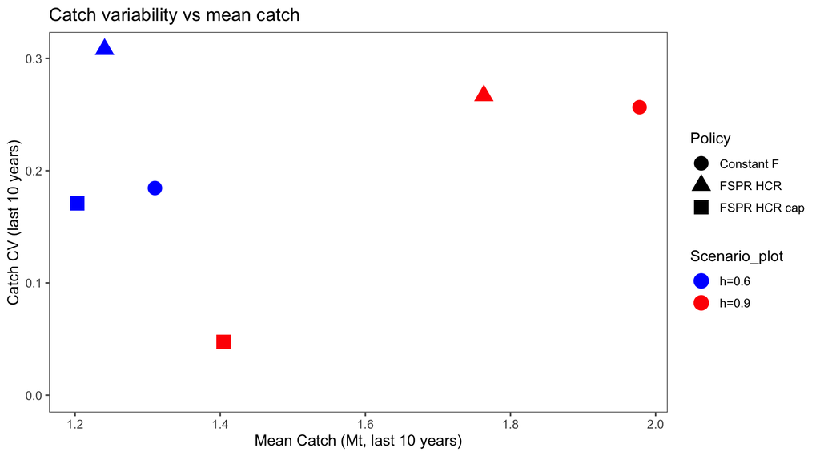

Figure 8: Average annual catch variability (CV) over the last 10 years versus mean catch over the last 10 years.

```r
catch_cap <- 1.45e9

last10_stats_constant <- function(scenario, f_multiplier, seed_base, n_sims) {
  params <- scenario$params
  ref_points <- scenario$ref_points
  n_years <- params$n_years
  last_years <- (n_years - 9):n_years

  mean_catch <- numeric(n_sims)
  cv_catch <- numeric(n_sims)

  for (i in 1:n_sims) {
    sim <- run_simulation(params, F_series = ref_points$Fmsy * f_multiplier, seed = seed_base + i)
    catch_last <- sim$Catch[last_years]
    mean_catch[i] <- mean(catch_last)
    cv_catch[i] <- sd(catch_last) / mean(catch_last)
  }

  data.frame(
    Scenario = scenario$name,
    Mean_Catch = mean_catch,
    Catch_CV = cv_catch,
    Policy = "Constant F"
  )
}

last10_stats_hcr <- function(scenario, F_target, B0, seed_base, n_sims, catch_cap, policy_label) {
  params <- scenario$params
  n_years <- params$n_years
  last_years <- (n_years - 9):n_years

  mean_catch <- numeric(n_sims)
  cv_catch <- numeric(n_sims)

  for (i in 1:n_sims) {
    sim <- run_simulation_hcr(
      params,
      F_target = F_target,
      B0 = B0,
      catch_cap = catch_cap,
      seed = seed_base + i
    )
    catch_last <- sim$Catch[last_years]
    mean_catch[i] <- mean(catch_last)
    cv_catch[i] <- sd(catch_last) / mean(catch_last)
  }

  data.frame(
    Scenario = scenario$name,
    Mean_Catch = mean_catch,
    Catch_CV = cv_catch,
    Policy = policy_label
  )
}

const_low_var <- last10_stats_constant(scenario_low, 1.0, seed_base = 1600, n_sims_points)
const_high_var <- last10_stats_constant(scenario_high, 1.0, seed_base = 1700, n_sims_points)
hcr_low_var <- last10_stats_hcr(
  scenario_low,
  F40_low,
  ref_low$SSB0,
  seed_base = 1800,
  n_sims_points,
  catch_cap = NULL,
  policy_label = "FSPR HCR"
)
hcr_high_var <- last10_stats_hcr(
  scenario_high,
  F40_high,
  ref_high$SSB0,
  seed_base = 1900,
  n_sims_points,
  catch_cap = NULL,
  policy_label = "FSPR HCR"
)
hcr_low_cap_var <- last10_stats_hcr(
  scenario_low,
  F40_low,
  ref_low$SSB0,
  seed_base = 2000,
  n_sims_points,
  catch_cap = catch_cap,
  policy_label = "FSPR HCR cap"
)
hcr_high_cap_var <- last10_stats_hcr(
  scenario_high,
  F40_high,
  ref_high$SSB0,
  seed_base = 2100,
  n_sims_points,
  catch_cap = catch_cap,
  policy_label = "FSPR HCR cap"
)

var_df <- rbind(const_low_var, const_high_var, hcr_low_var, hcr_high_var, hcr_low_cap_var, hcr_high_cap_var)
var_df$Scenario_plot <- ifelse(
  var_df$Scenario == scenario_low$name,
  "h=0.6",
  "h=0.9"
)

var_df$Mean_Catch_Mt <- var_df$Mean_Catch / 1e9

scenario_colors <- c("h=0.6" = "blue", "h=0.9" = "red")

var_summary <- aggregate(
  cbind(Mean_Catch_Mt, Catch_CV) ~ Scenario_plot + Policy,
  data = var_df,
  FUN = mean
)

p_var <- ggplot(var_summary, aes(x = Mean_Catch_Mt, y = Catch_CV, color = Scenario_plot, shape = Policy)) +
  geom_point(size = 5) +
  expand_limits(y = 0) +
  scale_color_manual(values = scenario_colors) +
  scale_shape_manual(values = c("Constant F" = 16, "FSPR HCR" = 17, "FSPR HCR cap" = 15)) +
  labs(x = "Mean Catch (Mt, last 10 years)", y = "Catch CV (last 10 years)", title = "Catch variability vs mean catch") +
  ggthemes::theme_few()

p_var
```

# 8 Conclusions

This comparison of low ($h = 0.6$) and high ($h = 0.9$) steepness scenarios demonstrates the critical influence of stock-recruitment steepness on fishery management. The main evidence comes from the reference points in Table 1 and the tradeoff patterns in Figure 1, Figure 2, and Figure 4.

## 8.1 Discussion

This simulation is a simplified, pollock-like evaluation of SPR-based control rules, grounded in the Tier 3 framework described in the BSAI FMP (North Pacific Fishery Management Council 2024). In this model, the proxy $F_{MSY}$ is $F_{40\%}$, with a sloping rule that holds $F_{40\%}$ above 0.4 $B_0$ and linearly ramps to zero at 0.05 $B_0$. That structure aligns with SPR proxy guidance and the literature on SPR-based reference points (North Pacific Fishery Management Council 2024; Szuwalski and Punt 2025), while remaining intentionally stylized to match the scenarios tested here.

The two steepness scenarios ($h = 0.6$ and $h = 0.9$) serve as a tractable proxy for productivity shifts discussed in climate and recruitment literature (Spencer et al. 2019; Punt et al. 2024; Szuwalski et al. 2023). We do not explicitly model environmental covariates or the ACLIM framework, but those references motivate the sensitivity analysis and the interpretation of performance differences across productivity regimes (Hollowed et al. 2020).

Finally, the catch-capped HCR variant (1.45 Mt) is a stylized analogue to ecosystem-cap effects that can dampen catch variability and conserve biomass during high abundance (Holsman et al. 2020; Ianelli et al. 2011). While the cap value here is illustrative and not a direct re-creation of the 2 Mt cap, the direction and intent are consistent with the cited findings, making the comparison appropriate for the simplified model context.

## 8.2 Reference Points

| Metric | h = 0.6 | h = 0.9 |
| --- | --- | --- |
| $F_{MSY}$ | 0.352 | 1.28 |
| $B_{MSY}$ | 2.66 Mt | 1.59 Mt |
| MSY | 1.31 Mt | 2 Mt |
| $B_{MSY}/SSB_0$ | 0.32 | 0.19 |

## 8.3 Key Findings

1. **Higher steepness dramatically increases sustainable fishing mortality**: $F_{MSY}$ increases from 0.35 to 1.28 (a 264% increase).
2. **MSY is 53% higher** with high steepness (2 vs 1.31 million tonnes).
3. **$B_{MSY}$ is lower** with high steepness because recruitment remains high even at reduced biomass levels.
4. **Management implications**: Uncertainty in steepness translates directly to uncertainty in sustainable harvest levels. A stock managed as if $h = 0.9$ when true $h = 0.6$ would be at high risk of overfishing.
5. **F40% sloping HCR vs constant F**: The proxy Fmsy (F40%) with the sloping control rule yields a different catch/SSB tradeoff than the constant-F multipliers, and its mean realized F/Fmsy and outcomes shift between $h = 0.6$ and $h = 0.9$ (see Figure 6 and Figure 7).

# 9 References

Hollowed, A. B., J. N. Ianelli, P. A. Livingston, B. Planque, and W. S. Wooster. 2020. “Changed States of the North Pacific Ecosystem.” *ICES Journal of Marine Science* 77: 886–97.

Holsman, K. K., J. N. Ianelli, K. Aydin, and S. Zador. 2020. “Ecosystem-Based Fisheries Management Requires Ecosystem-Based Analysis.” *Frontiers in Marine Science* 7: 594.

Ianelli, J. N., K. K. Holsman, K. Aydin, and A. E. Punt. 2011. “Multi-Model Inference of Linkages Between Walleye Pollock and Pacific Cod Dynamics Across the North Pacific.” *Marine and Coastal Fisheries* 3 (1): 110–28.

North Pacific Fishery Management Council. 2024. *Fishery Management Plan for Groundfish of the Bering Sea and Aleutian Islands Management Area*. North Pacific Fishery Management Council.

Punt, A. E., C. S. Szuwalski, J. N. Ianelli, and A. B. Hollowed. 2024. “Evaluating Harvest Control Rules Under Ecosystem Change.” *ICES Journal of Marine Science* 81 (1): 45–62.

Spencer, P. D., J. N. Ianelli, A. B. Hollowed, A. E. Punt, and J. K. Parrish. 2019. “Modelling Spatiotemporal Dynamics of Walleye Pollock in the Bering Sea: A Long-Term Outlook.” *Fisheries Oceanography* 28 (2): 189–204.

Szuwalski, C. S., J. N. Ianelli, A. E. Punt, and P. D. Spencer. 2023. “Climate-Informed Recruitment Dynamics: Implications for Harvest Control Rules.” *Fisheries Research* 265: 106745.

Szuwalski, C. S., and A. E. Punt. 2025. “Steepness Uncertainty and Reference Points in Multistock Management.” *Canadian Journal of Fisheries and Aquatic Sciences*.

# Appendix: R Session Info

Session information is reported below to document the computational environment used to generate the figures and tables.

[session information not shown]